# Lecture 2 – Intermediate/Advanced BigQuery for GA4

IBM 6530 Marketing Analytics

Author

Angela Qian

Published

March 18, 2026

## 1 1. CTEs with WITH

```sql
WITH UserInfo AS (
  SELECT
    user_pseudo_id,
    MAX(IF(event_name IN ('first_visit', 'first_open'), 1, 0)) AS is_new_user
  FROM `bigquery-public-data.ga4_obfuscated_sample_ecommerce.events_*`
  WHERE _TABLE_SUFFIX BETWEEN '20201101' AND '20201130'
  GROUP BY user_pseudo_id
)
SELECT
  COUNT(*) AS total_users,
  SUM(is_new_user) AS new_users
FROM UserInfo;
```

This query uses a Common Table Expression, or CTE, to create a temporary named result called UserInfo. Inside that CTE, each user is assigned a flag indicating whether they were a new user based on the presence of first_visit or first_open events. The outer query then summarizes the result into two metrics: total users and new users. This structure makes the logic much easier to read than writing everything in one long query.

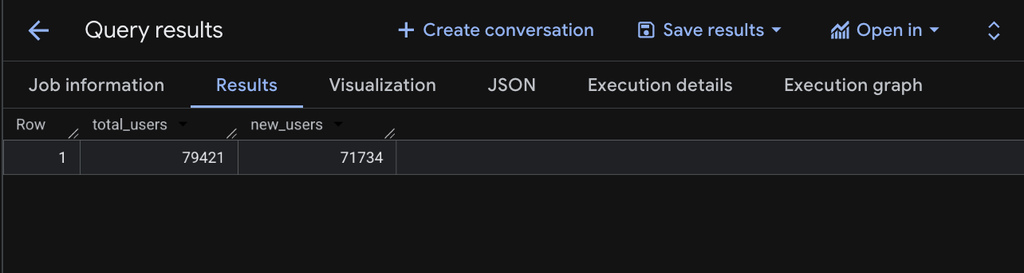

## 3 2. Arrays and UNNEST

### 3.1

### 3.2 2.1 Scalar Extraction from event_params

```sql
SELECT
  TIMESTAMP_MICROS(event_timestamp) AS event_time,
  (
    SELECT value.string_value
    FROM UNNEST(event_params)
    WHERE key = 'page_location'
    LIMIT 1
  ) AS page_location
FROM `bigquery-public-data.ga4_obfuscated_sample_ecommerce.events_*`
WHERE event_name = 'page_view'
  AND _TABLE_SUFFIX BETWEEN '20201201' AND '20201202'
LIMIT 50;
```

This query extracts the page_location parameter from the event_params array for page view events. Instead of exploding rows with a full UNNEST in the FROM clause, it uses a scalar subquery to safely pull just one value. This is useful when the goal is to preserve the original event-level grain while retrieving one specific parameter.

### 3.3

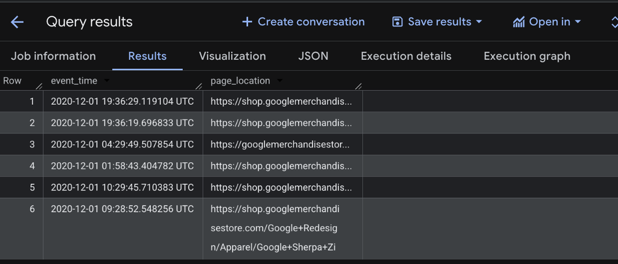

### 3.4 2.2 Flattening the items Array

```sql
SELECT
  event_date,
  item.item_name,
  COUNT(*) AS item_rows
FROM `bigquery-public-data.ga4_obfuscated_sample_ecommerce.events_*` e,
UNNEST(e.items) AS item
WHERE e.event_name = 'purchase'
  AND _TABLE_SUFFIX BETWEEN '20201201' AND '20201231'
GROUP BY event_date, item.item_name
ORDER BY item_rows DESC
LIMIT 20;
```

This query flattens the items array so that each item inside a purchase event becomes its own row. After unnesting, the grain changes from one row per event to one row per item per event. The query then counts how many times each item appears by date. This is one of the most important BigQuery patterns for GA4 ecommerce analysis because product-level information is nested inside arrays.

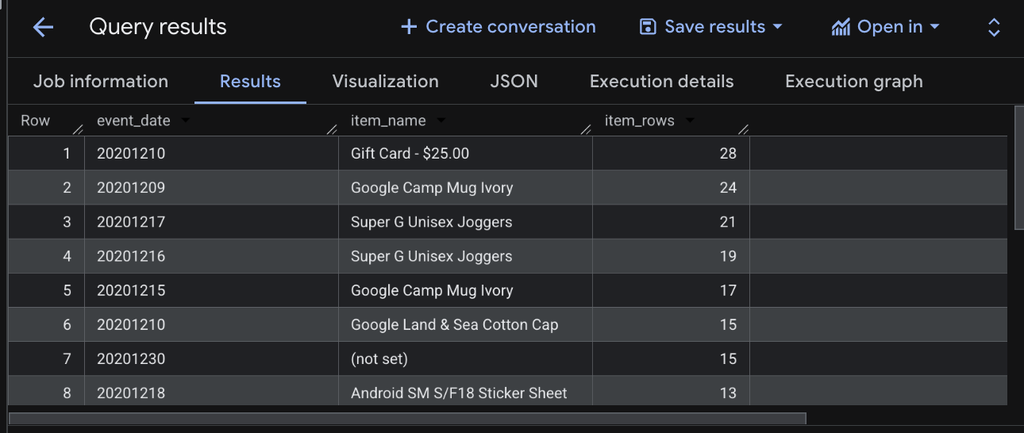

## 4 3. STRING_AGG and ARRAY_AGG

### 4.1 3.1 STRING_AGG Example

```sql
SELECT
  event_date,
  STRING_AGG(DISTINCT event_name, ', ' ORDER BY event_name) AS events_seen
FROM `bigquery-public-data.ga4_obfuscated_sample_ecommerce.events_*`
WHERE _TABLE_SUFFIX BETWEEN '20201201' AND '20201203'
GROUP BY event_date
ORDER BY event_date;
```

This query uses STRING_AGG to combine multiple event names into one comma-separated string per day. Because the query groups by event_date, each row in the output represents one day. The DISTINCT keyword prevents duplicate event names from being repeated, and the ORDER BY inside the aggregation keeps the list sorted. This is useful when summarizing categories into a readable format.

### 4.2

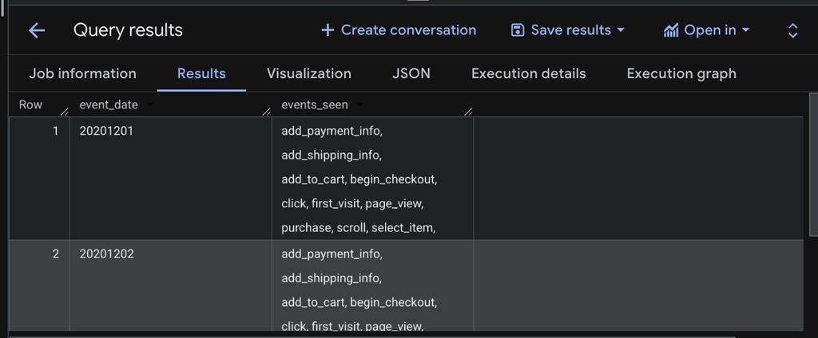

### 4.3 3.2 ARRAY_AGG Use Case 1

```sql
SELECT
  user_pseudo_id,
  ARRAY_AGG(item.item_name) AS items_added_to_cart
FROM `bigquery-public-data.ga4_obfuscated_sample_ecommerce.events_*`,
UNNEST(items) AS item
WHERE event_name = 'add_to_cart'
  AND _TABLE_SUFFIX BETWEEN '20201201' AND '20201231'
GROUP BY user_pseudo_id
ORDER BY user_pseudo_id
LIMIT 10;
```

This query uses ARRAY_AGG to collect all item names that a user added to cart into a single array. Since the data is grouped by user_pseudo_id, each output row represents one user. This makes it easy to summarize multiple cart actions into a compact user-level view.

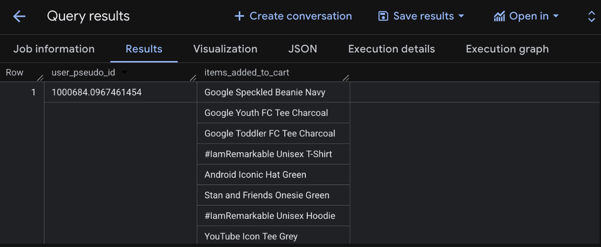

## 5

[figure not shown]

4. Joins

```sql
WITH daily_users AS (
  SELECT
    event_date,
    COUNT(DISTINCT user_pseudo_id) AS users
  FROM `bigquery-public-data.ga4_obfuscated_sample_ecommerce.events_*`
  WHERE _TABLE_SUFFIX BETWEEN '20201201' AND '20201231'
  GROUP BY event_date
),
daily_purchases AS (
  SELECT
    event_date,
    COUNT(DISTINCT (
      SELECT value.string_value
      FROM UNNEST(event_params)
      WHERE key = 'transaction_id'
    )) AS purchases
  FROM `bigquery-public-data.ga4_obfuscated_sample_ecommerce.events_*`
  WHERE event_name = 'purchase'
    AND _TABLE_SUFFIX BETWEEN '20201201' AND '20201231'
  GROUP BY event_date
)
SELECT
  u.event_date,
  u.users,
  IFNULL(p.purchases, 0) AS purchases,
  ROUND(
    IFNULL(p.purchases, 0) / NULLIF(u.users, 0) * 100, 2
  ) AS conversion_rate_pct
FROM daily_users u
LEFT JOIN daily_purchases p
  ON u.event_date = p.event_date
ORDER BY u.event_date;
```

This query joins two daily summaries: one for distinct users and one for distinct purchases. The LEFT JOIN ensures that every day from the users table appears in the final result, even if there were no purchases on that day. IFNULL replaces missing purchase values with zero, while NULLIF prevents division-by-zero errors when calculating the daily conversion rate. This is a useful pattern for building clean time-series reports.

## 6

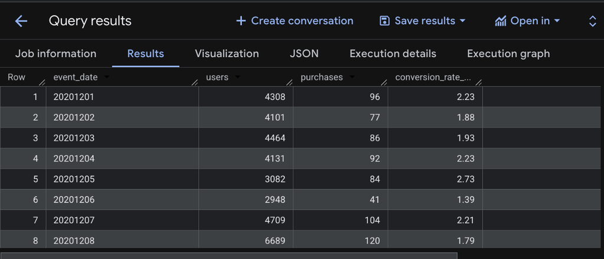

5. Window Functions and QUALIFY

### 6.1 5.1 Top 3 Event Types Per Day

```sql
WITH daily_event_counts AS (
  SELECT
    event_date,
    event_name,
    COUNT(*) AS events
  FROM `bigquery-public-data.ga4_obfuscated_sample_ecommerce.events_*`
  WHERE _TABLE_SUFFIX BETWEEN '20201201' AND '20201207'
  GROUP BY event_date, event_name
)
SELECT
  event_date,
  event_name,
  events,
  RANK() OVER (PARTITION BY event_date ORDER BY events DESC) AS rnk
FROM daily_event_counts
QUALIFY rnk <= 3
ORDER BY event_date, rnk;
```

This query first calculates event counts by day and event type, then uses a window function to rank event types within each day. Because RANK() is partitioned by event_date, the ranking restarts for every date. The QUALIFY clause filters the output after the window function is calculated, keeping only the top three event types per day.

## 7

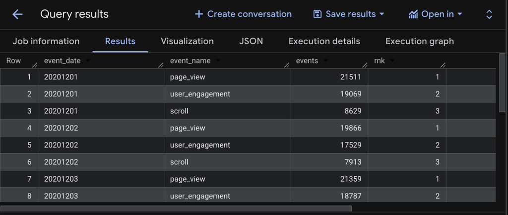

5.2 Rolling 7-Day Average of Purchases

```sql
WITH daily_purchases AS (
  SELECT
    PARSE_DATE('%Y%m%d', event_date) AS dt,
    COUNT(*) AS purchases
  FROM `bigquery-public-data.ga4_obfuscated_sample_ecommerce.events_*`
  WHERE event_name = 'purchase'
    AND _TABLE_SUFFIX BETWEEN '20201201' AND '20201231'
  GROUP BY dt
)
SELECT
  dt,
  purchases,
  AVG(purchases) OVER (
    ORDER BY dt
    ROWS BETWEEN 6 PRECEDING AND CURRENT ROW
  ) AS purchases_7d_avg
FROM daily_purchases
ORDER BY dt;
```

This query computes a rolling seven-day average of daily purchase counts. The CTE first builds one row per date, then the window function calculates the average over the current day and the previous six rows. This smooths short-term volatility and makes overall purchase trends easier to interpret.

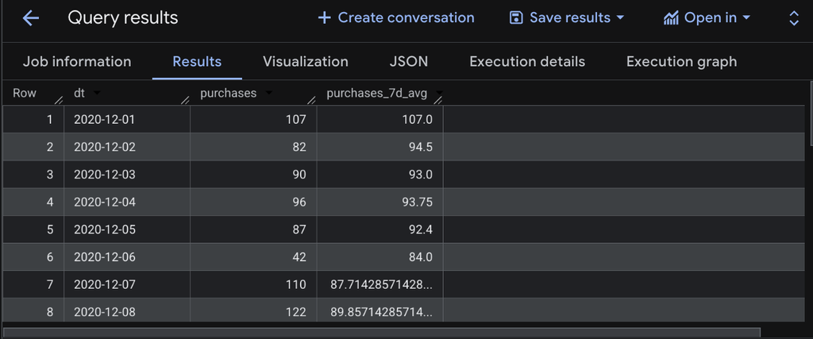

## 8 6.1 Approximate Functions

```sql
SELECT
  event_name,
  APPROX_COUNT_DISTINCT(user_pseudo_id) AS approx_users
FROM `bigquery-public-data.ga4_obfuscated_sample_ecommerce.events_*`
WHERE _TABLE_SUFFIX BETWEEN '20201201' AND '20201231'
GROUP BY event_name
ORDER BY approx_users DESC
LIMIT 15;
```

This query uses APPROX_COUNT_DISTINCT to estimate the number of unique users by event type. Compared with an exact distinct count, approximate functions are faster and more scalable on very large datasets. This makes them useful when speed matters more than perfectly exact precision.

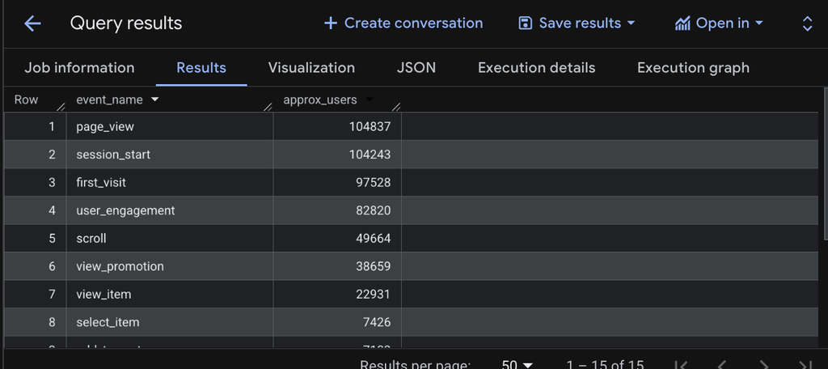

## 9 Final Reflection

Lecture 2 introduced more advanced BigQuery patterns that are especially useful for GA4 data because the schema is nested and event-driven. The most important takeaway for me was learning how arrays, UNNEST, joins, window functions, and approximate aggregation each change the way I think about grain, structure, and summarization. Compared with Lecture 1, this lecture felt much closer to real analytical workflows.